# Taller Bioestadística

Caso 2. Cardiovascular

Yeyson Fabian Riaño | Natalia Piraquive | André Vargas

## Clasificación de Variables

| Variable | Naturaleza | Continuidad | Escala de medida | Orientación descriptiva |
| --- | --- | --- | --- | --- |
| Edad | Cuantitativa | Continua | Razón | Independiente |
| Glucosa | Cuantitativa | Continua | Razón | Independiente |
| Colesterol total | Cuantitativa | Continua | Razón | Independiente |
| PAS | Cuantitativa | Continua | Razón | Independiente |
| PAD | Cuantitativa | Continua | Razón | Independiente |
| IMC | Cuantitativa | Continua | Razón | Independiente |
| Frec. cardiaca | Cuantitativa | Discreta | Razón | Independiente |
| Cigarrillos/día | Cuantitativa | Discreta | Razón | Independiente |
| Sexo | Cualitativa | NA | Nominal | Independiente |
| Fuma | Cualitativa | NA | Nominal | Independiente |
| Diabetes | Cualitativa | NA | Nominal | Independiente |
| Prev. hipertensión | Cualitativa | NA | Nominal | Independiente |
| Riesgo ECV 10 años | Cualitativa | NA | Nominal | Dependiente |

*Tabla 1. Listado de variables y su clasificación de la población estudiada*

## Análisis Variables Cuantitativas

- **Edad:** Distribución simétrica. La edad promedio es de 49.5 ± 9 años. El boxplot muestra que el 50% de los participantes se encuentra entre 42 y 56 años y no se observan valores atípicos.
- **Cigarrillos por día:** Distribución asimétrica positiva. La mediana igual a 0 sugiere que al menos el 50% de la población no fuma diariamente. El boxplot muestra valores atípicos superiores.
- **Colesterol total:** Distribución asimétrica positiva. El valor de la mediana se encuentra por encima del punto de corte, con una alta dispersión por rango intercuartil. El boxplot muestra valores atípicos principalmente superiores.
- **Presión sistólica:** Distribución asimétrica positiva. La mediana indica que al menos la mitad de la población presenta valores dentro del rango normal, con dispersión moderada. El boxplot muestra valores atípicos superiores.
- **Presión diastólica:** Distribución simétrica. La media se encuentra por debajo del punto de corte para hipertensión diastólica; sin embargo, presenta una dispersión significativa. El boxplot muestra gran cantidad de valores atípicos superiores.
- **IMC:** Distribución simétrica. El IMC promedio es de 25.8 ± 4 kg/m², con dispersión moderada alrededor del punto de corte para sobrepeso. El boxplot muestra valores atípicos superiores.
- **Frecuencia cardiaca:** Distribución simétrica. La frecuencia cardiaca promedio es 76 ± 12 lpm, dentro del rango normal. El boxplot evidencia principalmente valores extremos superiores.
- **Glucosa:** Distribución asimétrica positiva. La mediana indica glucemias dentro del rango normal. El boxplot muestra valores atípicos principalmente superiores.

> En conjunto, la distribución sugiere **heterogeneidad en el perfil cardiometabólico** de la población, identificando un posible subgrupo con valores elevados en estos factores de riesgo. Este patrón podría indicar acumulación de riesgo cardiovascular preexistente, aunque el diseño descriptivo no permite establecer causalidad ni diagnóstico clínico.

## Análisis Variables Cualitativas

En la población estudiada:

- Predominó el **sexo femenino (56.7%)**, mientras que el masculino representó el 43.3%.
- La prevalencia de **hipertensión arterial** estuvo presente en el **31.5%** de los participantes.
- El **tabaquismo** estuvo presente en el **49.8%** de los participantes.
- La **diabetes** estuvo presente en el **2.6%** de los participantes.
- La proporción de individuos que desarrollaron **riesgo cardiovascular a 10 años fue del 15.1%**.

> Aunque la frecuencia de diabetes es baja y el riesgo CV a 10 años es reducido, hay una alta prevalencia de tabaquismo e hipertensión, lo que respalda la **existencia de un grupo con acumulación de factores de riesgo**.

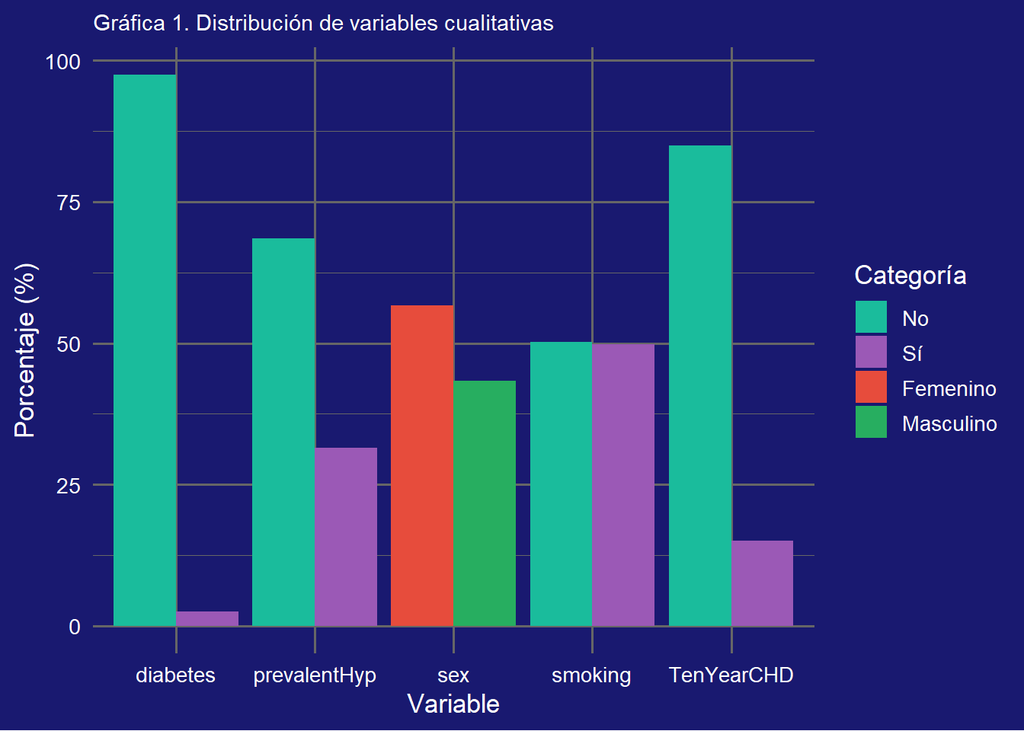

## Relación Factores de Riesgo según Sexo

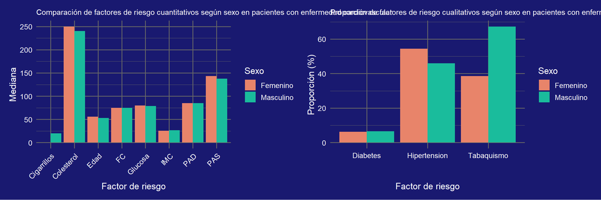

Las mujeres presentan **mayor edad, presión sistólica, colesterol total y prevalencia de hipertensión**, mientras que los hombres muestran **mayor consumo de cigarrillos y mayor IMC**. No se evidencian diferencias en presión diastólica, glucosa, frecuencia cardiaca y diabetes. El sexo actúa como un **modificador del perfil de riesgo**, más que como un factor aislado.

## Relación ECV con Edad y Presión Arterial

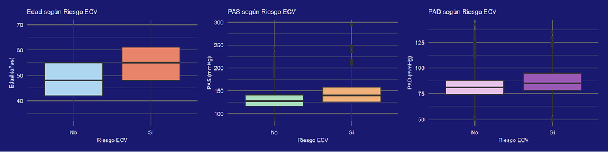

> **Estos hallazgos sugieren una relación positiva entre envejecimiento, elevación de la presión arterial y mayor presencia de enfermedad cardiovascular.**